# Homework 7

Anthony Ferraro

#### Filtering the Diamonds Dataset

```r
filtered_diamonds <- diamonds %>%
  filter(color %in% c("D", "G", "J")) %>%
  filter(clarity %in% c("I1", "VS1", "IF"))

knitr::kable(filtered_diamonds %>%
               count(color, clarity) %>%
               arrange(desc(n))
             )
```

| color | clarity | n |
| --- | --- | --- |
| G | VS1 | 2148 |
| D | VS1 | 705 |
| G | IF | 681 |
| J | VS1 | 542 |
| G | I1 | 150 |
| D | IF | 73 |
| J | IF | 51 |
| J | I1 | 50 |
| D | I1 | 42 |

[^1]

#### Plotting the Relationship Between Price and Carat

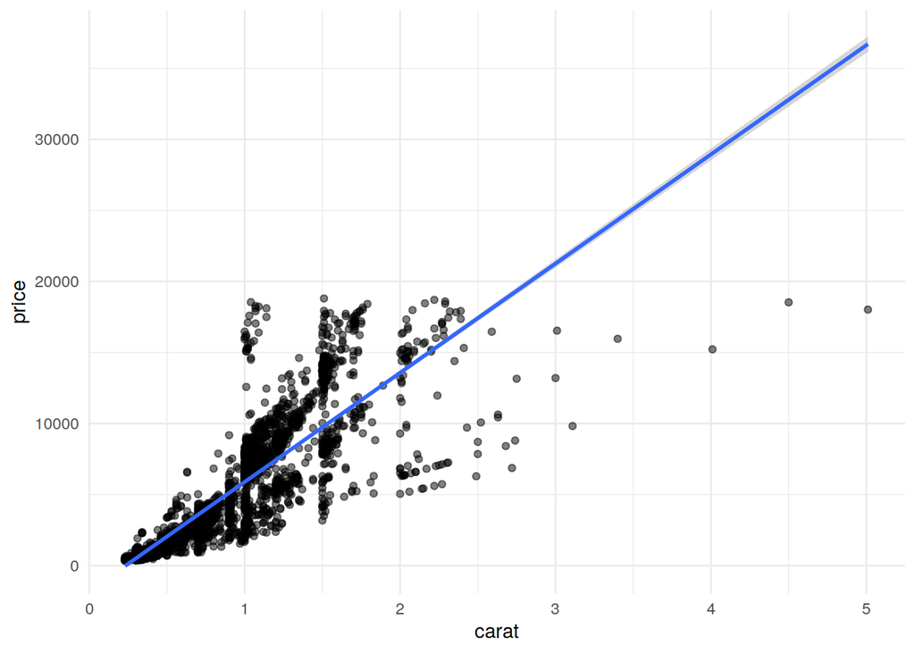

```r
ggplot(filtered_diamonds, aes(x = carat, y = price)) +
  geom_point(alpha = 0.5) +
  geom_smooth(method = "lm")
```

There seems to be a positive relationship between carat and price, which does make sense. Also, the relationship does seem to be linear. [^2]

#### Plotting the Relationship Between Price and Carat with Diamond Color

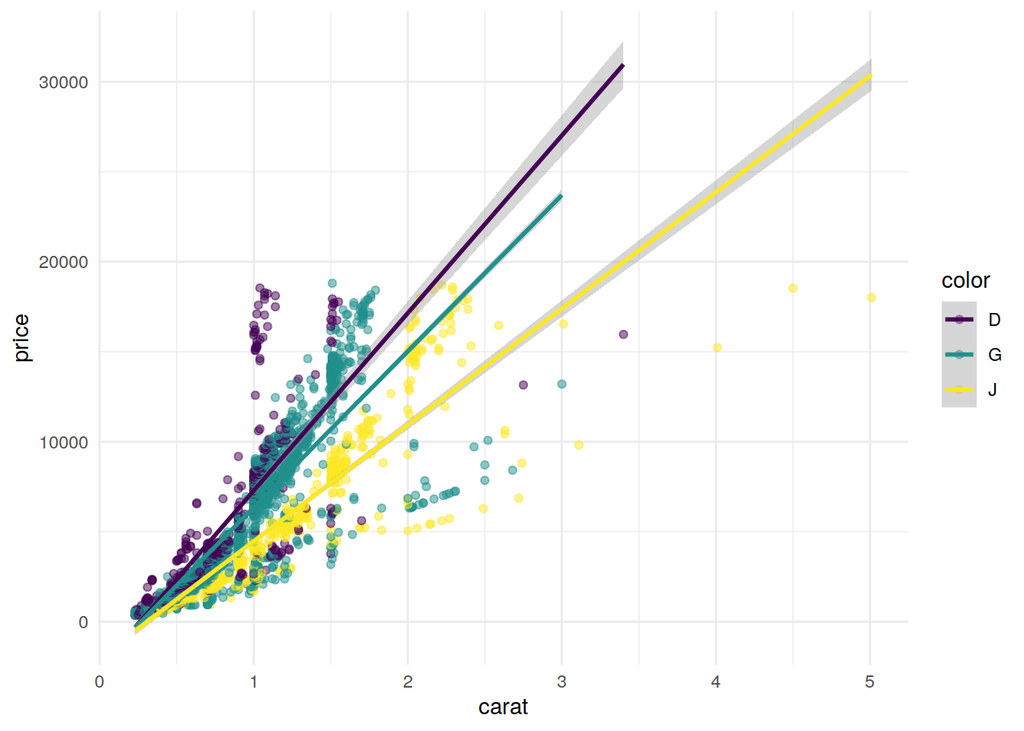

```r
ggplot(filtered_diamonds, aes(x = carat, y = price, color = color)) +
  geom_point(alpha = 0.5) +
  geom_smooth(method = "lm")
```

The relationship between carat and price is still positive and linear, however, it seems that some diamond colors have steeper price increases than others. [^3]

#### Plotting the Relationship Between Price and Carat with Diamond Color and Diamond Clarity

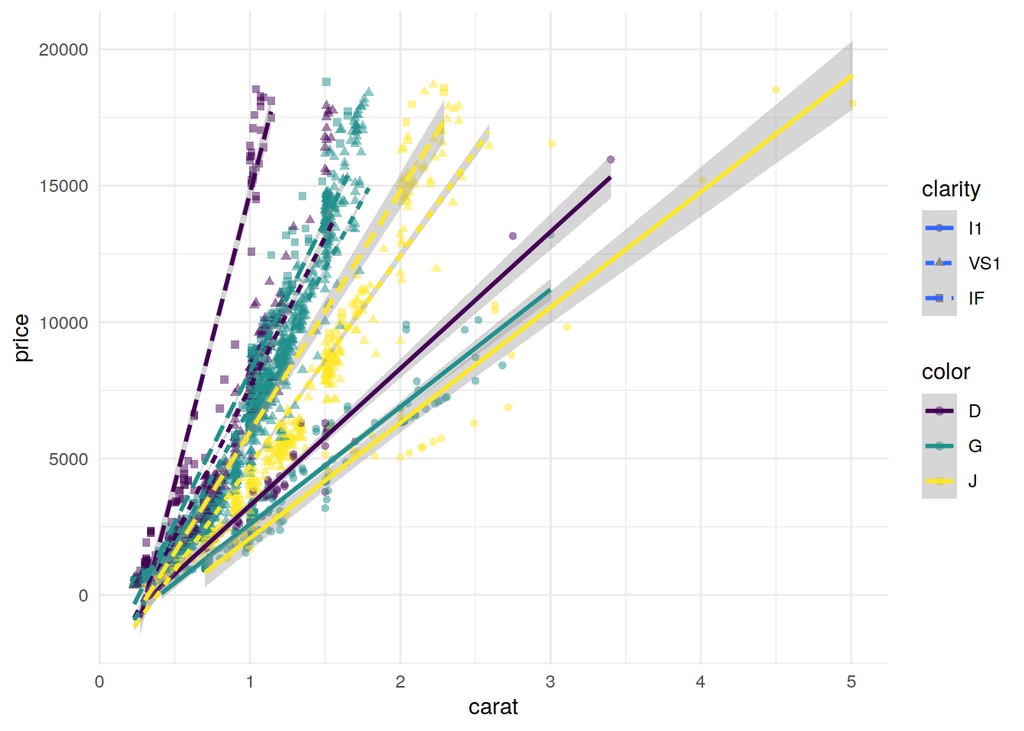

```r
ggplot(filtered_diamonds, aes(x = carat, y = price, color = color, shape = clarity,
                              linetype = clarity)) +
  geom_point(alpha = 0.5) +
  geom_smooth(method = "lm")
```

I think that adding clarity in this way makes the graph harder to read as there are too many different shapes, colors, and line types on the graph. [^4]

#### Plotting the Relationship Between Price and Carat with Diamond Color and Clarity Faceted

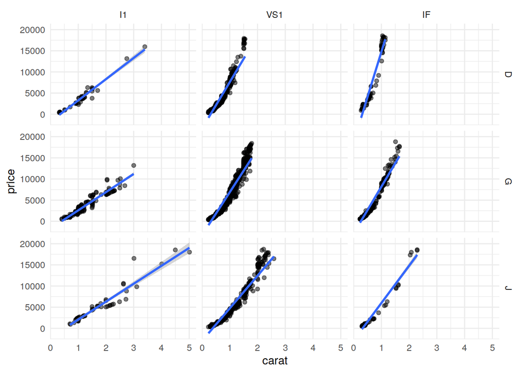

```r
ggplot(filtered_diamonds, aes(x = carat, y = price)) +
  geom_point(alpha = 0.5) +
  geom_smooth(method = "lm") +
  facet_grid(color ~ clarity)
```

Most of the carat vs. price relationships are still linear, although some look like they are almost exponential. The steepest relationship is between D color and IF clarity, which makes sense because they are the best for their respective categories. [^5]

#### Finding the Highest Price Per Carat Ratio

```r
knitr::kable(filtered_diamonds %>%
  mutate(price_per_carat = (price / carat)) %>%
  group_by(color, clarity) %>%
  summarize(avg_price_pc = mean(price_per_carat)) %>%
  arrange(desc(avg_price_pc))
)
```

| color | clarity | avg_price_pc |
| --- | --- | --- |
| D | IF | 9937.419 |
| G | VS1 | 4420.881 |
| D | VS1 | 4204.891 |
| G | IF | 4007.010 |
| J | VS1 | 3750.351 |
| J | IF | 3220.227 |
| D | I1 | 3064.485 |
| J | I1 | 2710.080 |
| G | I1 | 2617.478 |

The table does seem to agree with my plots, with the D color and IF clarity combination being the highest price per carat, and the G color and I1 clarity combination being the lowest price per carat. [^6]

[^1]: Question 1 Complete
[^2]: Question 2 Complete
[^3]: Question 3 Complete
[^4]: Question 4 Complete
[^5]: Question 5 Complete
[^6]: Question 6 Complete